# Real-world Data Wrangling

## 5. Answer the research question

### **5.1:** Define and answer the research question

Going back to the problem statement in step 1, use the cleaned data to answer the question you raised. Produce **at least** two visualizations using the cleaned data and explain how they help you answer the question.

*Research question:* What, if any, correlation is there between the El Nino phenomenon and global temperatures?

```python
# # If the next cell returns an error, try installing matplotlib first
# %pip install matplotlib
```

```python
import matplotlib.pyplot as plt
```

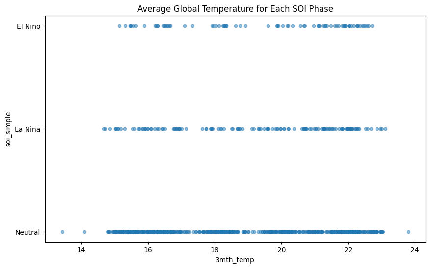

```python
# Plot showing relation between El Nino phase classification and global temps
combined_data.plot(x='3mth_temp', y='soi_simple', kind='scatter', alpha=0.5, figsize=(10,6),
                   title='Average Global Temperature for Each SOI Phase');
```

*Answer to research question:* Visually, it is hard to determine any correlation between global temperatures and El Nino. The El Nino observations appear to be slightly denser at higher temps, and La Nina observations appear to be more evenly spread.

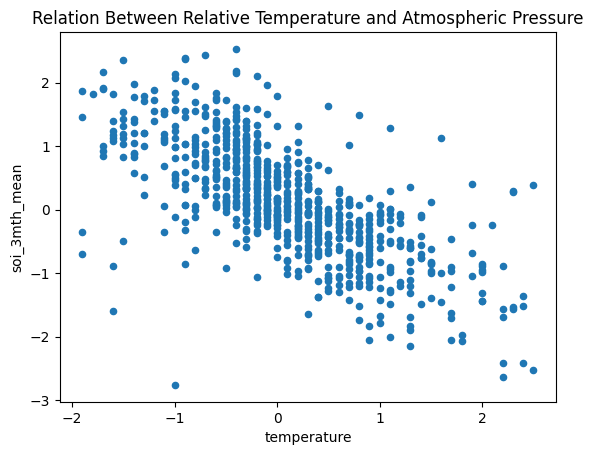

```python
# Create scatter plot showing the relation between oceanic temp and atmospheric pressure; I noticed earlier that positive SOI values
# tended to correlate to negative temperature values and vice-versa
combined_data.plot(x='temperature', y='soi_3mth_mean', kind='scatter')
plt.title('Relation Between Relative Temperature and Atmospheric Pressure');
```

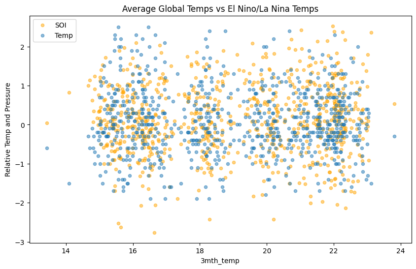

```python
# Scatter plot showing relation between relative ocean temp and atmospheric pressure and global temps
ax = combined_data.plot(x='3mth_temp', y='soi_3mth_mean', kind='scatter', alpha=0.5, color='Orange', label='SOI')
combined_data.plot(x='3mth_temp', y='temperature', kind='scatter',alpha=0.5, ax=ax, figsize=(10,6),
                   title='Average Global Temps vs El Nino/La Nina Temps', ylabel='Relative Temp and Pressure', label='Temp');
```

*Answer to research question:* The relative temperatures and atmospheric pressures are negatively correlated with each other, but do not seem to have a significant correlation with global temperatures.

### **5.2:** Reflection

In 2-4 sentences, if you had more time to complete the project, what actions would you take? For example, which data quality and structural issues would you look into further, and what research questions would you further explore?

*Answer:* The global temperature data I imported was separated by country. Ideally, I would have only used temperature data for countries near the equatorial pacific ocean, where El Nino is observed. Weather aspects other than temperature also would have been good to gather, such as precipitation and wind speed. For the ENSO and RONI datasets, the data was averaged across locations, and finding a dataset where location was also given would have likely given a more robust conclusion.